# NOAA Temperature and Precipitation Data

Data for Eastern Shore Region

Tolu Odukoya and Lee LeBoeuf

11/30/2021

# Data Source

- The Climate Divisional Dataset from the National Center For Environmental Information began as the only long-term temporally and spatially complete dataset from which to generate historical climate analyses (1895-2021) for the contiguous United States (CONUS). It was originally developed for climate division, statewide, regional, national, and population-weighted monitoring of drought, temperature, precipitation, and heating/cooling degree day values.
- There are 344 climate divisions in the CONUS. For each climate division, monthly station temperature and precipitation values are computed from the daily observations. The divisional values are weighted by area to compute statewide values and the statewide values are weighted by area to compute regional values. (Karl and Koss, 1984).
- To learn more, see: [National Center For Environmental Information and Data](https://www.ncdc.noaa.gov/monitoring-references/maps/us-climate-divisions.php#grdd)
- Data are available for download [here](https://www.ncei.noaa.gov/pub/data/cirs/climdiv/)
  - Maximum Temperature: climdiv-tmaxcy-v1.0.0
  - Minimum Temperature: climdiv-tmincy-v1.0.0
  - Precipitation: climdiv-pcpncy-v1.0.0

## The Data Used Here

- The data used here represent county-level measures for localities in the Eastern Shore region (Accomack, Northampton). While NOAA includes information on a variety of climate measures, we focus on the following measures for the year 1895-2021:
  - Monthly and annual average maximum temperature (degrees F) for each county
  - Monthly and annual average minimum temperature (degrees F) for each county
  - Monthly and annual average precipitation (inches) for each county

## Variable Descriptions

```r
noaa_shape2020 <- noaa_shape %>%
  filter(year == "2020") %>%
  select(STATEFP, COUNTYFP, NAME, year:Decpcp)

kbl(noaa_shape2020) %>%
  kable_paper(full_width = F) %>%
   scroll_box(width = "800px", height = "350px")
```

| STATEFP | COUNTYFP | NAME | year | Avg_Tempmin | Avg_Tempmax | Avg_monthlypcp | Tot_yearlypcp | Janmin | Febmin | Marmin | Aprmin | Maymin | Junmin | Julmin | Augmin | Sepmin | Octmin | Novmin | Decmin | Janmax | Febmax | Marmax | Aprmax | Maymax | Junmax | Julmax | Augmax | Sepmax | Octmax | … |
| --- | --- | --- | --- | --- | --- | --- | --- | --- | --- | --- | --- | --- | --- | --- | --- | --- | --- | --- | --- | --- | --- | --- | --- | --- | --- | --- | --- | --- | --- | --- |
| 51 | 001 | Accomack | 2020 | 51 | 69 | 5 | 55.07 | 34.2 | 35.5 | 42.7 | 44.9 | 53.7 | 65.7 | 73.0 | 71.2 | 63.5 | 54.6 | 44.6 | 34.3 | 51.8 | 54.0 | 60.5 | 64.3 | 70.0 | 83.1 | 90.1 | 85.8 | 78.7 | 72.2 | … |
| 51 | 131 | Northampton | 2020 | 52 | 69 | 5 | 57.56 | 35.3 | 36.4 | 44.5 | 46.1 | 54.9 | 66.5 | 73.1 | 71.7 | 64.4 | 56.0 | 45.4 | 34.9 | 53.1 | 54.9 | 61.8 | 65.1 | 70.2 | 82.1 | 90.9 | 86.2 | 77.8 | 71.4 | … |

## Summary Statistics

```r
noaa %>% select(-year) %>%
  select(where(~is.numeric(.x) && !is.na(.x))) %>%
  as.data.frame() %>%
  stargazer(., type = "text", title = "Summary Statistics", digits = 1,
            summary.stat = c("mean", "sd", "min", "median", "max"))
```

```
##
## Summary Statistics
## =============================================
## Statistic      Mean St. Dev. Min  Median Max
## ---------------------------------------------
## Avg_Tempmin    48.8   1.4    45.0  49.0  52.0
## Avg_Tempmax    66.1   1.5    62.0  66.0  70.0
## Avg_monthlypcp 3.5    0.6    2.0   3.0   5.0
## Tot_yearlypcp  42.7   6.5    23.2  41.8  59.6
## Janmin         29.5   4.3    17.7  29.1  41.1
## Febmin         29.8   3.9    17.2  30.2  37.4
## Marmin         36.9   3.4    26.3  36.7  46.8
## Aprmin         45.3   2.4     40   45.2   54
## Maymin         55.1   2.6    47.8  55.0  63.4
## Junmin         64.2   2.3    58.2  64.3  70.9
## Julmin         69.3   1.9    64.5  69.2  74.1
## Augmin         68.1   1.9    63.3  68.1  72.9
## Sepmin         62.5   2.5    55.7  62.5  70.4
## Octmin         51.6   3.3    44.2  51.6  60.5
## Novmin         40.7   2.9    33.1  40.5  50.2
## Decmin         32.5   3.8    22.5  32.6  46.2
## Janmax         46.2   4.6    32.9  46.0  59.2
## Febmax         47.3   4.8    34.1  47.6  59.4
## Marmax         54.9   4.2    42.1  55.2  66.7
## Aprmax         64.3   3.0    55.4  64.2  72.4
## Maymax         73.5   2.7    67.3  73.2  81.0
## Junmax         81.3   2.4    72.6  81.4  88.2
## Julmax         85.7   2.1    81.2  85.5  91.4
## Augmax         84.3   2.0    78.5  84.2  89.3
## Sepmax         79.0   2.3     72   78.8   85
## Octmax         69.3   2.6     64   69.3   77
## Novmax         58.6   3.0    49.2  58.5  65.3
## Decmax         49.2   4.4    38.2  49.6  62.5
## Janpcp         3.4    1.4    0.8   3.2   9.6
## Febpcp         3.3    1.4    0.5   3.2   7.9
## Marpcp         3.9    1.6    0.2   3.7   9.9
## Aprpcp         3.1    1.2    0.4   3.0   6.3
## Maypcp         3.3    1.6    0.3   2.9   8.2
## Junpcp         3.6    1.5    0.4   3.5   9.1
## Julpcp         4.6    2.0    0.5   4.3   13.2
## Augpcp         4.5    2.4    0.6   3.9   11.8
## Seppcp         3.6    2.1    0.3   3.0   12.9
## Octpcp         3.2    1.8    0.03  2.9   9.8
## Novpcp         2.8    1.6    0.1   2.4   8.6
## Decpcp         3.3    1.5    0.6   3.1   8.1
## ---------------------------------------------
```

# Maps, Warming Stripes, and Timeplots

- The goal of the project is to identify the effects of climate change on the hot weather patterns in the counties. We chose July as the month of interest because it is often the hottest month of the year.

## July Temperatures

### Maximum Temperature in July across Counties for all Years

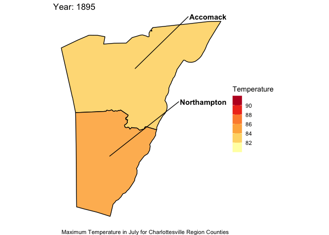

```r
county_points <- st_centroid(noaa_shape)
county_points <- county_points %>%
  mutate(lat = st_coordinates(.)[,1],
         lon = st_coordinates(.)[,2])

#noaa_shape <- cbind(noaa_shape, st_coordinates(st_centroid(noaa_shape)))

july_temp <-
  ggplot(noaa_shape) +
  geom_sf(aes(fill = Julmax), color = "black", alpha = .9, na.rm = TRUE) +
  geom_text_repel(data = county_points, aes(x = lat, y = lon, label = NAME), size = 4,
                   nudge_x = 1, nudge_y = 0.30, fontface = "bold", direction = "y",
                   point.padding = 0.5) +
  scale_fill_fermenter(palette = "YlOrRd", direction = 1, type = "seq", n.breaks = 7) +
  theme_void() +
  guides(fill = guide_colourbar(title.position="top", title.hjust = 0.5,
                           barwidth = 1))  +
  labs(fill = "Temperature ", title = 'Year: {frame_time}',
       caption = "Maximum Temperature in July for Charlottesville Region Counties",
       size = 10) +
 transition_time(as.integer(year)) +
ease_aes('linear')

animate(july_temp, fps = 1, detail = 1, nframes = 127)
```

```r
meta %>%
  filter(varname == "Julmax") %>%
  select(about) %>%
  as.list()
```

$about [1] “July Maximum Temperature for a given year and county in degrees Fahrenheit”

### Minimum Temperature in July across Counties for all Years

- This is an interactive graph. Click on the graph to zoom, scroll through each year to see numeric temperature readings for all counties for each year.

```r
dygraph(cville_sf1x, main = "Minimum Temperature in July across Counties for all Years", ylab = "Temperature (F)") %>%
  dySeries("Accomack", label = "Accomack") %>%
  dySeries("Northampton", label = "Northampton") %>%
  dyHighlight(highlightCircleSize = 3,
              highlightSeriesBackgroundAlpha = 0.2,
              hideOnMouseOut = FALSE, highlightSeriesOpts = list(strokeWidth = 3)) %>%
dyLegend(show = "always", hideOnMouseOut = FALSE, width = 400) %>%
    dyRangeSelector(height = 20) %>%  dyOptions(colors = RColorBrewer::brewer.pal(6, "Set2"))
```

[interactive chart not shown]

```r
meta %>%
  filter(varname == "Julmin") %>%
  select(about) %>%
  as.list()
```

$about [1] “July Minimum Temperature for a given year and county in degrees Fahrenheit”

## Average Yearly Maximum Temperatures by County

```r
#select only the annual temperature and year column
cville_sf1_yr <- select(noaa_shape, NAME, year, Avg_Tempmax)

#rename the temperature column
cville_sf1_yr <- rename(cville_sf1_yr, ta = Avg_Tempmax)
```

```r
#create a date column because stripes only works with format = date

cville_sf1_yr <- mutate(cville_sf1_yr, date = str_c(year, "01-01", sep = "-") %>% ymd())
```

```r
#Filter out each County. No need to do theme again it's already set
cville_sf1_yrg <- filter(cville_sf1_yr, NAME == "Accomack")
cville_sf1_yra <- filter(cville_sf1_yr, NAME == "Northampton")
```

```r
#Create the theme for the stripes image

theme_strip <- theme_minimal()+
                 theme(axis.text.y = element_blank(),
                       axis.line.y = element_blank(),
                       axis.title = element_blank(),
                       panel.grid.major = element_blank(),
                       legend.title = element_blank(),
                       legend.text = element_text(size = 10),
                       axis.text.x = element_text(vjust = 3, size = 10),
                       panel.grid.minor = element_blank(),
                        plot.title = element_text(size = 15, face = "bold"),
                       plot.caption = element_text(size = 10)

                       )


col_strip <- brewer.pal(11, "RdBu")
```

### Accomack County Warming Stripes: Average Yearly Maximum Temperature

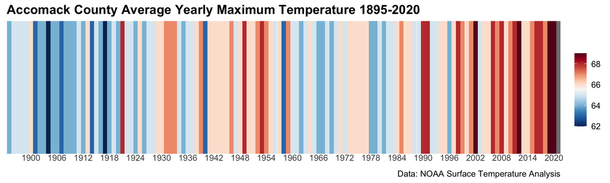

```r
 ggplot(cville_sf1_yrg,
             aes(x = date, y = 1, fill = ta))+
        geom_tile()+
           scale_x_date(date_breaks = "6 years",
                     date_labels = "%Y",
                     expand = c(0, 0))+
           scale_y_continuous(expand = c(0, 0))+
           scale_fill_gradientn(colors = rev(col_strip))+
             guides(fill = guide_colorbar(barwidth = 1))+
            labs(title = "Accomack County Average Yearly Maximum Temperature 1895-2020",
                caption = "Data: NOAA Surface Temperature Analysis")+
              theme_strip
```

### Northampton County Warming Stripes: Average Yearly Maximum Temperature

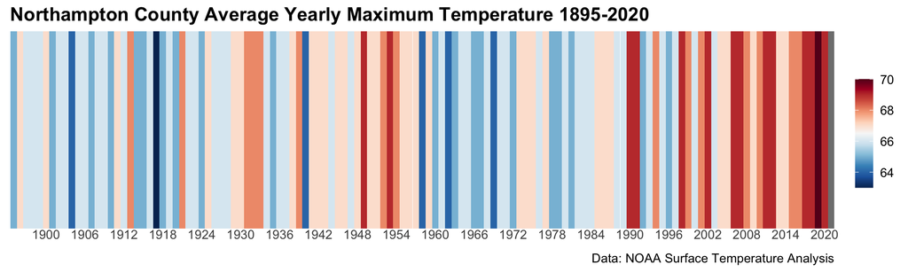

```r
 ggplot(cville_sf1_yra,
             aes(x = date, y = 1, fill = ta))+
        geom_tile()+
           scale_x_date(date_breaks = "6 years",
                     date_labels = "%Y",
                     expand = c(0, 0))+
           scale_y_continuous(expand = c(0, 0))+
           scale_fill_gradientn(colors = rev(col_strip))+
             guides(fill = guide_colorbar(barwidth = 1))+
            labs(title = "Northampton County Average Yearly Maximum Temperature 1895-2020",
                caption = "Data: NOAA Surface Temperature Analysis")+
              theme_strip
```

## Total Yearly Precipitation

```r
dygraph(cville_sf1xp, main = "Total Yearly Precipitation across Counties for all Years", ylab = "Precipitation") %>%
  dySeries("Accomack", label = "Accomack") %>%
  dySeries("Northampton", label = "Northampton") %>%
  dyHighlight(highlightCircleSize = 3,
              highlightSeriesBackgroundAlpha = 0.2,
              hideOnMouseOut = FALSE, highlightSeriesOpts = list(strokeWidth = 3)) %>%
dyLegend(show = "always", hideOnMouseOut = FALSE, width = 400) %>%
    dyRangeSelector(height = 20) %>%  dyOptions(colors = RColorBrewer::brewer.pal(6, "Set2"))
```

[interactive chart not shown]

```r
meta %>%
  filter(varname == "Tot_yearlypcp") %>%
  select(about) %>%
  as.list()
```

$about [1] “Total Yearly Precipitation for a given year and county in Inches”